# Lee_Spencer_Module_4_Jupyter_Notebook

## Module 4: Cancer Hallmarks and Machine Learning Models

## Team Members:

Grace Lee, Kiran Spencer

## Project Title:

Using Machine Learning Models To Indentify Relationships Between Cancer Hallmarks and in Brain Lower Grade Glioma and Treatment Options

## Project Goal:

This project seeks to determine whether there is a significant relationship between the hallmarks of resisting apoptosis and genome instability in brain lower grade glioma.

## AI Usage Statement

Artificial Intelligence was used in this project as a tool to assist with pandas data analysis and the machine learning model coding poritions, and to help interpret some of the results from PCA analyses, etc. Additionally, AI was used to aid a preliminary literature search for relationship between certain genome instabiltiy and resisting apoptosis genes.

## Disease Background:

- **Cancer hallmark focus:** The focus for this project is on two primary hallmarks of resisting apoptosis and genomic instability.
- **Cancer focus:** This project focuses on hallmark expression specifically within low-grade glioma (LGG) patients.

#### Cancer Hallmark Exploration

**Resist apoptosis:**

Mutations in certain genes cause damaged cells to multiply, instead of undergoing apoptosis. For example, a mutation in the TP53 gene produces a faulty p53 transcription factor. Normally, p53 helps to destroy a damaged cell, but the mutant p53 continues to allow for cell growth. This genetic mutation is seen in many different cancer types, being present in 50% of all human tumor growths (Hamzehloie et al., 2012).

**Genome instability:**

This characteristic of cancer causes cancer cells to divide into different mutated “subclones”, causing heterogeneity and diversity in cancer cells within the same tumor. Additionally, the same cancer type can develop into tumors that look vastly different between different patients. LGGs are a heterogeneous set of gliomas affected by this genome instability cancer hallmark (Cao et al., 2022).

##### Associated Hallmark Genes:

For preliminary exploration, we were interested in exploring the relationship between certain gene pairs of genome instability and resisting apoptosis genes and how they interacted, such as the relationship between TP53 and BIRC5, ATRX and MCL1, and MGMT and BAX.

**TP53 and BIRC5**

TP53: this gene is known as the "guardian of the genome" for its integral role in regulating cell death. TP53 encodes for p53, which is a transcription factor that signals for the destruction of damaged cells. In LGG, mutant TP53 causes damaged cells to resist cell death and continue to grow uncontrollably, additionally contributing to the genome instability hallmark.

BIRC5: this gene is also known as survivin, and has been shown to increase cell proliferation by inhibiting apoptosis (Jiang et al., 2022). Higher expression of BIRC5 has been shown to be positively correlated to more adverse manifestations of LGG. TP53 usually represses BIRC5, but mutant TP53 lifts the control and may cause a surge in BIRC5, preventing the damaged cell from dying.

**ATRX and MCL1:**

ATRX: this gene is involved in the stabilization chromatin and cell cycle regulation. Without ATRX, DNA damage and replicative stress has been shown to occur, leading to genome instability.

MCL1: this gene is found to be frequently amplified in all human cancers, including LGG (Zhang et al., 2023). With loss of ATRX, there is expected to be higher MCL1 levels in order to combat the genomic instability caused by the mutant ATRX.

**MGMT and BAX:**

MGMT: MGMT normally protects against damage alkylating DNA damage. However, in LGG, this gene can be silenced and causes cells to accumulate mutations and further genomic instability.

BAX: this gene normally responds to DNA damage and causes apoptosis. However, in LGG, lower expression of this gene can allow cells with damaged DNA that went unchecked by MGMT to persist and survive.

#### Low-Grade Glioma Disease Background

- Prevalence & incidence

Low-grade gliomas (LGGs) have an incidence rate of around 1.12 per 100,000 people (Cao et al., 2023). When examining sex differences, incidence rates were lower in females than males. Different subtypes of LGGs also had different incidence rates, with the highest incidence rate being astrocytomas (0.43 per 100,000 people). Incidence rates peak in individuals aged 30-40 (Forst et al., 2014).

- Risk factors & Societal determinants

Exact risk factors of LGGs are not well understood. However, previous exposure to ionizing radiation or radiation therapies can increase the risk of developing LGGs (Karsonovich et al., 2025). Additionally, while LGGs are diagnosed more commonly in younger individuals, survival outcomes of LGG decreases with older age. LGG is also more commonly found in males (Cao et al., 2023).

From a genetic standpoint, having a specific allele of CCDC26 on chromosome 8 has also been identified as a risk factor, with this allele seen in 40% of patients with certain gliomas, while only 8% of the general population has this allele (Toader et al., 2023). Additionally, mutations in isocitrate dehydrogenase (IDH) 1 and 2 are present in more than 80% of LGG tumors (Bready & Placantonakis, 2019).

- Standard of care treatments

Surgery to remove the tumor is the primary treatment method for LGG. For grade 1 gliomas, surgery may commpletely removing the tumor and cure the disease. However, if the cancerous growth is not completely removed by surgery, other treatment options include targeted therapies, chemotherapy, and radiation therapy. Targeted therapies is becoming a top treatment option, as medicines can specifically target the cancer cells and shrink the tumor without as many side effects as chemotherapy or radiation therapy (Low-grade glioma treatment).

- Biological mechanisms

Gliomas are a subset of central nervous system (CNS) tumors that affect glial cells. Glial cells are the most abundant cells in the CNS, and provide essential functions such as forming myelin, and supporting neurons in the nervous system (Ludwig & Das, 2023). Low-grade gliomas (LGG) include grade 1 and grade 2 gliomas, which are relatively slow-growing and less aggressive (Toader et al., 2023).

Genetic mutations in tumor suppressor protein 53 (p53) and epidermal growth factor receptor (EGFR) contribute to LGG growth. The mutated p53 does not function properly to destroy cells with faulty DNA, and amplificatin of EGFR causes cells to divide uncontrollably (Karsonovich et al., 2025). Additionally, mutations in IDH1 and 2 increase tumorigenesis (Schaff et al., 2024). The result of these mutations is slow growth of "undifferentiated, proliferating stem-like tumor cells" (Bready & Placantonakis, 2019).

## Data-Set:

The dataset was aquired using next generation sequencing methods to allow millions of cDNA fragments to be sequenced simultaneously. Then, the raw sequences are mapped back the the reference human genome to determine which specific genes the RNA fragments came from and allows for their number to be quantified.

Because the raw counts can be biased by gene length or the total depth of the sequencing run, the data is normalized. Reads per kilobase (RPK) adjusts for the fact that longer genes naturally produce more fragments, transcipts per million (TPM) further normalizes the number of reads of a sample, making it possible to compare different cancer samples directly, and log-transformation of the TPM values stabilizes the variance in the data, making it easier to perform statistical comparisons between cancer types.

This dataset was collected from The Cancer Genome Atlas RNA-seq dataset, and re-processed by Rahman et al.

### Initial Exploratory Analyis:

```python
import pandas as pd # Importing pandas for data manipulation
import matplotlib.pyplot as plt # Importing matplotlib for plotting
import seaborn as sns # Importing seaborn for enhanced data visualization

# 1. LOAD DATA
# ------------------------------------------------------------------
data = pd.read_csv('../Data/TRAINING_SET_GSE62944_subsample_log2TPM.csv', index_col=0, header=0)
metadata_df = pd.read_csv('../Data/TRAINING_SET_GSE62944_metadata.csv', index_col=0, header=0)

# 2. EXPLORATORY DATA ANALYSIS (EDA) QUESTIONS
# ------------------------------------------------------------------

print("--- GLOBAL EXPLORATORY ANALYSIS ---")

# 1. Global Min and Max log(TPM+1)

print(f"Global Minimum value: {data.values.min()}")
print(f"Global Maximum value: {data.values.max()}")

# 2. Average expression across all genes

all_gene_means = data.mean(axis=1)
print(f"Average expression across all genes: {all_gene_means.mean():.4f}")

# 3. Genes with the highest average expression

print("\nTop 5 genes with highest average expression:")
print(all_gene_means.sort_values(ascending=False).head(5))
```

```
--- GLOBAL EXPLORATORY ANALYSIS ---
Global Minimum value: 0.0
Global Maximum value: 17.41027960374137
Average expression across all genes: 3.7168

Top 5 genes with highest average expression:
ACTB     12.594034
FTL      12.525603
TPT1     12.476975
B2M      12.347839
GAPDH    12.160252
dtype: float64
```

Based on the intial exploratory analysis, the minimum log(TPM+1) value in the dataset is 0.0 and the maximum is 17.4. The average expression across all genes is 3.7168. The top 5 genes with the highest average expression are ACTB, FTL, TPT1, B2M, and GAPDH.

### Hallmark Relationships of Brain Lower Grade Glioma:

To analyze the molecular landscape of Brain Lower Grade Glioma (LGG), the code utilizes the pandas library to perform high-precision filtering on the TCGA RNA-seq dataset. We first filtered by cancer type, targeting the "cancer_type" column and isolating the "LGG" label. Once these specific samples are extracted, the code subsets the expression data to only include the genes related to the hallmarks of Genome Instability and Resisting Apoptosis, as described in the hallmarks background section. This ensures that the subsequent statistical analysis is both computationally efficient and biologically relevant. We found that there were 80 LGG samples, providing an effective number to conduct statistical analysis methods.

Following the isolation of these hallmark signatures, the code prepares the data for quantitative comparison by transposing the matrix data so that individual genes serve as variables across the patient cohort. The code then generates descriptive statistics (such as mean, variance, and standard deviation) to evaluate the distribution of expression levels across the LGG samples, ensuring the data is suitable for linear analysis. This statistical grounding allows for the calculation of correlation coefficients for the three specific gene pairs, determining the strength and direction of the relationships between genome integrity and apoptotic resistance. Finally, the analysis produces linear regression plots that visually map these interactions, such as the coupling between TP53 and BIRC5, providing insight into how glioma cells may decouple their internal damage sensors from their programmed cell death machinery.

```
IDENTIFIED COHORT SIZE: 80 LGG samples found.

--- DESCRIPTIVE STATISTICS FOR HALLMARK GENES (log2TPM) ---
       count      mean       50%       std  variance       min       max
BIRC5   80.0  2.984246  2.868732  1.554941  2.417840  0.211229  6.768166
BAX     80.0  6.530347  6.459001  0.555367  0.308432  5.405714  8.340613
ATRX    80.0  4.459433  4.429314  0.863545  0.745710  2.051763  6.525204
MGMT    80.0  4.048077  4.165652  0.939512  0.882683  2.004635  6.071811
TP53    80.0  5.701409  5.883111  0.837045  0.700644  3.307865  7.226927
MCL1    80.0  7.481947  7.426584  0.596206  0.355461  6.278707  9.575612

--- PAIRWISE CORRELATION SUMMARY ---
Correlation between TP53 and BIRC5: 0.4288
Correlation between ATRX and MCL1: -0.0188
Correlation between MGMT and BAX: 0.0286
```

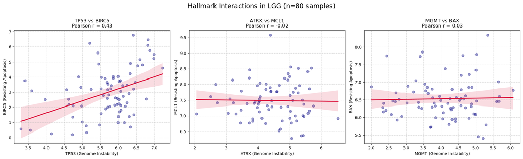

```python
import pandas as pd
import matplotlib.pyplot as plt
import seaborn as sns

# 1. LOAD DATA
# ------------------------------------------------------------------
# Loading the subsampled log2TPM expression data and associated metadata
data = pd.read_csv('../Data/TRAINING_SET_GSE62944_subsample_log2TPM.csv', index_col=0, header=0)
metadata_df = pd.read_csv('../Data/TRAINING_SET_GSE62944_metadata.csv', index_col=0, header=0)

# 2. FILTER FOR LGG SAMPLES
# ------------------------------------------------------------------
# Isolate samples identified as Brain Lower Grade Glioma (LGG)
lgg_samples = metadata_df[metadata_df['cancer_type'] == 'LGG'].index
lgg_data = data[lgg_samples]

# Identify and report the size of the patient cohort
num_samples = len(lgg_samples)
print(f"IDENTIFIED COHORT SIZE: {num_samples} LGG samples found.\n")

# 3. DEFINE THREE SPECIFIC PAIRS (Genome Instability vs. Apoptosis)
# ------------------------------------------------------------------
# Based on the Hallmarks of Cancer, we select three gene pairs that represent key interactions:
pairs = [
    ('TP53', 'BIRC5'), # Pair 1: Master Regulator link
    ('ATRX', 'MCL1'),  # Pair 2: Chromatin/Survival link
    ('MGMT', 'BAX')    # Pair 3: Repair/Death link
]

# Extract unique genes from pairs and verify their presence in the dataset
target_genes = list(set([gene for pair in pairs for gene in pair]))
available_genes = [g for g in target_genes if g in lgg_data.index]
missing = set(target_genes) - set(available_genes)

if missing:
    print(f"WARNING: {missing} not in dataset. These pairs will be skipped.\n")

# Transpose the data: Rows become Samples (Barcodes), Columns become Genes
lgg_subset = lgg_data.loc[available_genes].T

# 4. SUMMARY STATISTICS
# ------------------------------------------------------------------
print("--- DESCRIPTIVE STATISTICS FOR HALLMARK GENES (log2TPM) ---")
# .describe() provides count, mean, std, and quartiles
stats = lgg_subset.describe().T
# Adding variance to evaluate the spread/heterogeneity of expression
stats['variance'] = lgg_subset.var()

# Printing specific metrics for each gene
print(stats[['count', 'mean', '50%', 'std', 'variance', 'min', 'max']])

print("\n--- PAIRWISE CORRELATION SUMMARY ---")
for gi_gene, ra_gene in pairs:
    if gi_gene in available_genes and ra_gene in available_genes:
        r_val = lgg_subset[gi_gene].corr(lgg_subset[ra_gene])
        print(f"Correlation between {gi_gene} and {ra_gene}: {r_val:.4f}")

# 5. VISUALIZE THE RELATIONSHIPS
# ------------------------------------------------------------------
# Set up a 1x3 grid for the three hallmark interaction plots
fig, axes = plt.subplots(1, 3, figsize=(18, 5))

for i, (gi_gene, ra_gene) in enumerate(pairs):
    if gi_gene in available_genes and ra_gene in available_genes:
        corr_val = lgg_subset[gi_gene].corr(lgg_subset[ra_gene])

        # Plot regression line and scatter points
        sns.regplot(ax=axes[i], data=lgg_subset, x=gi_gene, y=ra_gene,
                    scatter_kws={'alpha':0.4, 'color':'navy'},
                    line_kws={'color':'crimson'}) # Adding a regression line for better visualization of the relationship

        axes[i].set_title(f"{gi_gene} vs {ra_gene}\nPearson r = {corr_val:.2f}")
        axes[i].set_xlabel(f"{gi_gene} (Genome Instability)")
        axes[i].set_ylabel(f"{ra_gene} (Resisting Apoptosis)")
        axes[i].grid(True, linestyle='--', alpha=0.6)
    else:
        axes[i].text(0.5, 0.5, 'Gene Missing', ha='center', fontsize=12, color='red')

plt.tight_layout() # Adjust layout to prevent overlap
plt.suptitle(f"Hallmark Interactions in LGG (n={num_samples} samples)", y=1.08, fontsize=16)
plt.show()
```

## Data Analysis:

### Methods

LGG patient samples were first analyzed through PCA and subsequent PCA loadings, UMAP, and K-means clustering to best visualize the dataset and determine what machine learning model we would proceed to fit to the data. After running these analyses, we moved forward with the supervised machine learning technique of linear regression. Regularization techniques, such as lasso, ridge, and elastic net regularization was applied in order to see if the model could be further optimized.

### Analysis: PCA

To first analyze the data, the dataset was reduced to just the patients with Brain Low Grade Glioma, particularly focusing on the gene expression associated with the two hallmarks of Genome Instability and Resisting Apoptosis. Then, PCA analysis was conducted to identify intitial variance within the reduced dataset.

```python
# Importing libraries for clustering and dimensionality reduction
import pandas as pd # Pandas for data manipulation
import numpy as np # Numpy for numerical operations
import matplotlib.pyplot as plt # Matplotlib for plotting
from sklearn.cluster import KMeans # KMeans for clustering
import seaborn as sns # Seaborn for enhanced data visualization
from sklearn.decomposition import PCA # PCA for dimensionality reduction

# Load the data
####################################################
data = pd.read_csv(
    '../Data/TRAINING_SET_GSE62944_subsample_log2TPM.csv', index_col=0, header=0)  # can also use larger dataset with more genes
metadata_df = pd.read_csv(
    '../Data/TRAINING_SET_GSE62944_metadata.csv', index_col=0, header=0)
hallmarks = pd.read_csv('../data/Menyhart_JPA_CancerHallmarks_core.txt', sep = '\t', index_col = 0, header = None)
```

[output not shown]

[output cut: 47 more lines]

```
NEIL3       0.154281
Name: PC1, dtype: float64

Top PC2 genes (Genome Instability):
 PTTG1      0.195195
ATM        0.168505
ERCC6      0.166352
UBR5       0.160610
TP53BP1    0.159869
BARD1      0.158266
WRN        0.158039
ATRX       0.154582
SMC1A      0.152490
PRKDC      0.149268
Name: PC2, dtype: float64
```

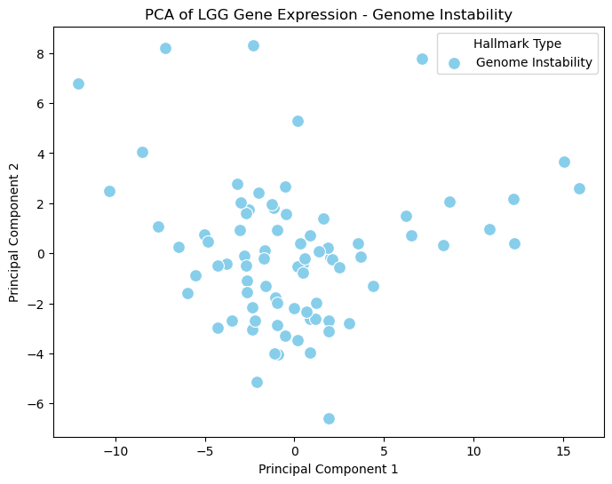

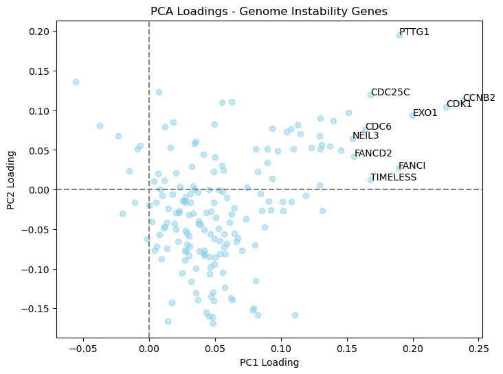

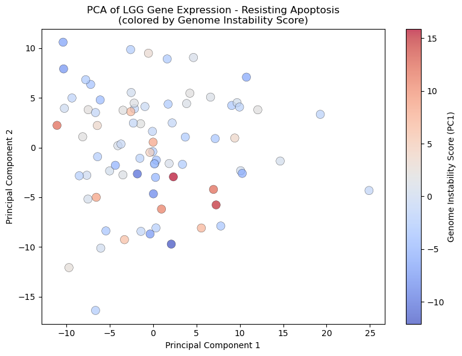

```
=== Resisting Apoptosis Loadings ===
             PC1       PC2
STAT1   0.079114  0.023340
RIPK1   0.042614 -0.010562
CYCS   -0.008363  0.021041
MAP3K8  0.092775  0.017418
RHOA    0.017116  0.007861
...          ...       ...
MAP3K5  0.014437  0.070539
MYB     0.009622 -0.012456
MAP2K5 -0.024192  0.005865
MLH1   -0.008412 -0.010347
RPS6   -0.016996 -0.032812

[406 rows x 2 columns]

Top PC1 genes (Resisting Apoptosis):
 SOCS3     0.187006
CD44      0.166905
BCL2A1    0.155293
CAMK2A    0.149237
CASP1     0.143707
IL6       0.140377
CSF1R     0.137881
IL1B      0.136231
ITGB4     0.135592
FOS       0.130009
Name: PC1, dtype: float64

Top PC2 genes (Resisting Apoptosis):
 CAMK2A    0.303337
PRKCB     0.184435
SNCA      0.175974
PAK1      0.157637
FGFR2     0.138667
FGFR3     0.133301
IL1B      0.127781
ANGPT2    0.127699
TLR4      0.127464
NRG3      0.126359
Name: PC2, dtype: float64
```

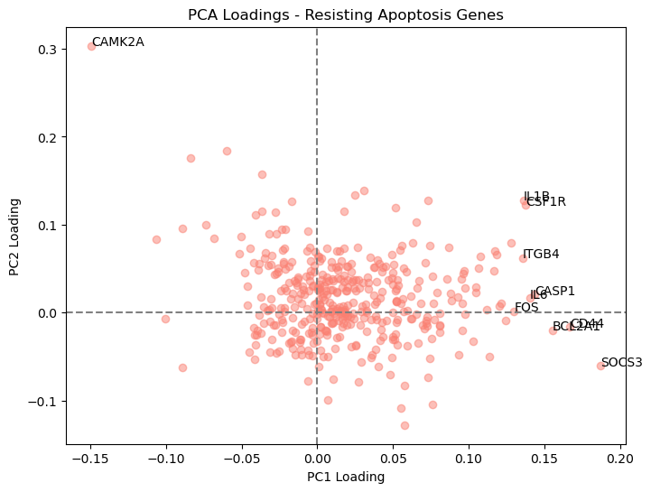

```python
# Subset the data for a specific cancer type
####################################################
cancer_type = 'LGG'  # Low-Grade Glioma

cancer_samples = metadata_df[metadata_df['cancer_type'] == cancer_type].index
print(cancer_samples)
LGG_data = data[cancer_samples]

# Subset by index (genes)
####################################################
desired_gene_list_genome_instability = hallmarks.loc['GENOME INSTABILITY'].dropna().tolist()
desired_gene_list_resist_apoptosis = hallmarks.loc['RESISTING CELL DEATH'].dropna().tolist()

# Genome instability genes
gene_list_genome_instability = [gene for gene in desired_gene_list_genome_instability if gene in LGG_data.index]
for gene in desired_gene_list_genome_instability:
    if gene not in gene_list_genome_instability:
        print(f"Warning: {gene} not found in the dataset.")

LGG_gene_data_genome_instability = LGG_data.loc[gene_list_genome_instability] # Subset the LGG data to include only the genome instability genes

# Resisting apoptosis genes
gene_list_resist_apoptosis = [gene for gene in desired_gene_list_resist_apoptosis if gene in LGG_data.index]
for gene in desired_gene_list_resist_apoptosis:
    if gene not in gene_list_resist_apoptosis:
        print(f"Warning: {gene} not found in the dataset.")

LGG_gene_data_resist_apoptosis = LGG_data.loc[gene_list_resist_apoptosis] # Subset the LGG data to include only the resisting apoptosis genes

X = LGG_gene_data_genome_instability.T # Transpose to have samples as rows and genes as columns
X2 = LGG_gene_data_resist_apoptosis.T # Transpose to have samples as rows and genes as columns
y = metadata_df.loc[X.index, 'cancer_type'] # Aligning the cancer type labels with the samples in X
y2 = metadata_df.loc[X2.index, 'cancer_type'] # Aligning the cancer type labels with the samples in X2


# PCA - Genome Instability
####################################################
pca_genome = PCA(n_components=2)
X_pca = pca_genome.fit_transform(X)

# Loadings
loadings_genome = pd.DataFrame(
    pca_genome.components_.T,
    index=X.columns,
    columns=['PC1', 'PC2']
)

print("=== Genome Instability Loadings ===")
print(loadings_genome)

top_pc1_genome = loadings_genome['PC1'].abs().sort_values(ascending=False).head(10) # Get top 10 genes contributing to PC1
top_pc2_genome = loadings_genome['PC2'].abs().sort_values(ascending=False).head(10) # Get top 10 genes contributing to PC2
print("\nTop PC1 genes (Genome Instability):\n", top_pc1_genome)
print("\nTop PC2 genes (Genome Instability):\n", top_pc2_genome)

# Plot PCA scatter
plt.figure(figsize=(8, 6))
sns.scatterplot(
    x=X_pca[:, 0],
    y=X_pca[:, 1],
    color='skyblue',
    label='Genome Instability',
    s=100
) # Scatter plot of PCA results for genome instability genes
plt.title("PCA of LGG Gene Expression - Genome Instability")
plt.xlabel("Principal Component 1")
plt.ylabel("Principal Component 2")
plt.legend(title="Hallmark Type")
plt.show()

# Plot loadings
plt.figure(figsize=(8, 6))
plt.scatter(loadings_genome['PC1'], loadings_genome['PC2'], alpha=0.5, color='skyblue') # Plotting loadings for genome instability genes
top_genes_genome = loadings_genome['PC1'].abs().nlargest(10).index
for gene in top_genes_genome:
    plt.annotate(gene, (loadings_genome.loc[gene, 'PC1'], loadings_genome.loc[gene, 'PC2']))
plt.axhline(0, color='gray', linestyle='--')
plt.axvline(0, color='gray', linestyle='--')
plt.xlabel("PC1 Loading")
plt.ylabel("PC2 Loading")
plt.title("PCA Loadings - Genome Instability Genes")
plt.show()


# PCA - Resisting Apoptosis
####################################################
pca_apoptosis = PCA(n_components=2)
X2_pca = pca_apoptosis.fit_transform(X2)

# Compute genome instability score (PC1 from genome instability PCA)
genome_instability_score = pd.Series(X_pca[:, 0], index=X.index)

# Align scores to apoptosis samples
score_aligned = genome_instability_score.loc[X2.index]

# Plot Resisting Apoptosis PCA colored by Genome Instability Score
plt.figure(figsize=(8, 6))
scatter = plt.scatter(
    X2_pca[:, 0],
    X2_pca[:, 1],
    c=score_aligned,
    cmap='coolwarm',
    alpha=0.7,
    s=100,
    edgecolors='k',
    linewidths=0.3
) # Scatter plot of PCA results for resisting apoptosis genes colored by genome instability score
plt.colorbar(scatter, label='Genome Instability Score (PC1)')
plt.title("PCA of LGG Gene Expression - Resisting Apoptosis\n(colored by Genome Instability Score)")
plt.xlabel("Principal Component 1")
plt.ylabel("Principal Component 2")
plt.tight_layout()
plt.show()

# Loadings
loadings_apoptosis = pd.DataFrame(
    pca_apoptosis.components_.T,
    index=X2.columns,
    columns=['PC1', 'PC2']
) # Create a DataFrame for the loadings of the resisting apoptosis PCA

print("=== Resisting Apoptosis Loadings ===")
print(loadings_apoptosis)

top_pc1_apoptosis = loadings_apoptosis['PC1'].abs().sort_values(ascending=False).head(10) # Get top 10 genes contributing to PC1
top_pc2_apoptosis = loadings_apoptosis['PC2'].abs().sort_values(ascending=False).head(10) # Get top 10 genes contributing to PC2
print("\nTop PC1 genes (Resisting Apoptosis):\n", top_pc1_apoptosis)
print("\nTop PC2 genes (Resisting Apoptosis):\n", top_pc2_apoptosis)


# Plot loadings
plt.figure(figsize=(8, 6))
plt.scatter(loadings_apoptosis['PC1'], loadings_apoptosis['PC2'], alpha=0.5, color='salmon') # Plotting loadings for resisting apoptosis genes
top_genes_apoptosis = loadings_apoptosis['PC1'].abs().nlargest(10).index
for gene in top_genes_apoptosis:
    plt.annotate(gene, (loadings_apoptosis.loc[gene, 'PC1'], loadings_apoptosis.loc[gene, 'PC2']))
plt.axhline(0, color='gray', linestyle='--')
plt.axvline(0, color='gray', linestyle='--')
plt.xlabel("PC1 Loading")
plt.ylabel("PC2 Loading")
plt.title("PCA Loadings - Resisting Apoptosis Genes")
plt.show()
```

#### PCA Results

##### Genome Instability – PCA Plot

In this plot, there is a high density of points near the origin with specific outliers streaking along the positive x-axis (PC1). The tight cluster suggests that a majority of LGG patients share a baseline transcriptomic signature of genome instability. Biologically, this likely represents the standard mutational load seen in these gliomas, which are relatively slow growing. The outliers along the PC1 axis represent patients whose genome instability genes are behaving in an unusual way, which can correspond to a more aggressive cancer.

##### Genome Instability – PCA Loading Plot

The labeled genes indicate which genes most heavily influenced the principal component axes identified in the genome instability PCA graph. The majority of the datapoints on the PCA loading plot have positive PC1 loadings, suggesting that most of the identified genome instability genes are positively correlated with PC1. If a patient sample scores higher on PC1, that suggests a general upregulation of genome instability gene expression. The top 10 genes with the largest absolute PC1 loadings were labeled, meaning they contributed the strongest to the PC1 axis.

##### Resisting Apoptosis – PCA plot colored by genome instability

This plot shows a much higher dispersion of points. The wide variation on both PC1 and PC2 indicate that Resisting Apoptosis is a more diverse hallmark in LGG than Genome Instability, as there are many possible ways for glioma cells to avoid death. The PCA graph is colored by genome instability scores taken from the genome instability PCA graph. The aim is to figure out if samples clustering on the Resisting Apoptosis PCA plot have similar genome instability expression. The genome instability colors are largely randomly dispersed, and there does not appear to be a distinct pattern of genome instability coloring on the PCA graph, suggesting that there may not be a very strong relationship between the variances in genome instability and resisting apoptosis genes.

##### Resisting Apoptosis – PCA loading plot

Similarly to the Genome Instability PCA loading plot, this graph analyzes how much different resisting apoptosis genes affect the axes of the PCA plot. Points lie on both the positive and negative side of the PC1 loading axis, suggesting that some hallmark genes have opposing mechanisms and pathways in resisting apoptosis, further confirming that Resisting Apoptosis is a more diverse hallmark in LGG. The labeled gene CAM2KA exists as an outlier with a high absolute PC1 loading score. However, its position on the PC loading graph in the upper left, as opposed to the other labeled genes near the bottom right of the graph, indicates that CAM2KA behaves very differently from the rest of the genes largely influencing PC1.

### UMAP

To further explore the local relationships between patients, we utilized UMAP (Uniform Manifold Approximation and Projection) to project the combined hallmark features into two dimensions. Unlike PCA, which captures linear variance, UMAP allows us to see how patients group into specific clusters based on non-linear similarities in their gene expression.

In this projection, each point represents an LGG patient sample. The algorithm identifies clusters by looking at the closest neighbors for each patient in high-dimensional gene-space. In doing so, UMAP can reveal subgroups that might be hidden in a standard linear analysis. This is especially useful for understanding the diverse ways that resisting apoptosis genes might interact with the genome instability hallmark.

Within this projected space, we applied K-Means clustering to identify three distinct patient subgroups. This partitioning helps us see if the diversity observed in our initial PCA plots actually forms stable, biologically distinct clusters rather than just random scatter. By grouping the 80 samples into these clusters, we can better analyze the specific transcriptomic signatures that define each group.

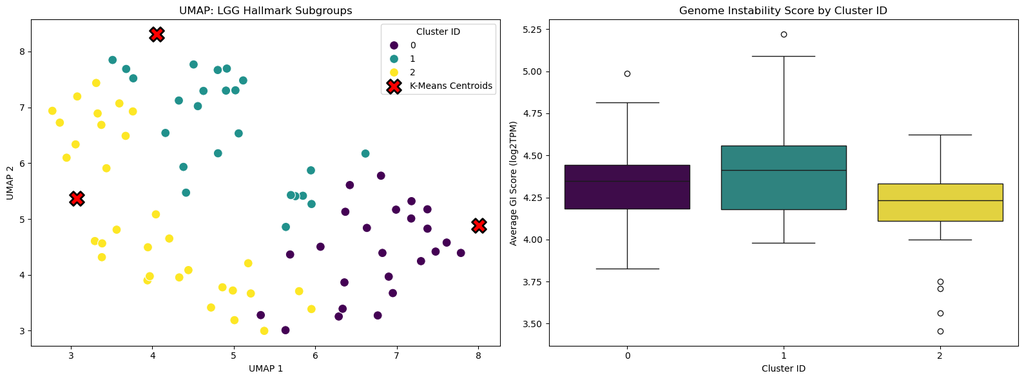

```python
import umap # UMAP for dimensionality reduction
from sklearn.cluster import KMeans #` KMeans for clustering
import seaborn as sns # Seaborn for enhanced data visualization
import matplotlib.pyplot as plt # Matplotlib for plotting
import pandas as pd # Pandas for data manipulation

# 1. CALCULATE HALLMARK SCORES
# ------------------------------------------------------------------
X['GI_Score'] = X.mean(axis=1)
X2_mean = X2.mean(axis=1)

# 2. COMBINE FEATURES FOR UNSUPERVISED LEARNING
# ------------------------------------------------------------------
X_combined = pd.concat([X.drop(columns=['GI_Score']), X2], axis=1)

# 3. K-MEANS CLUSTERING
# ------------------------------------------------------------------
kmeans = KMeans(n_clusters=3, random_state=42)
combined_clusters = kmeans.fit_predict(X_combined)

# 4. UMAP DIMENSIONALITY REDUCTION
# ------------------------------------------------------------------
reducer = umap.UMAP(n_neighbors=15, min_dist=0.1, random_state=42)
X_umap = reducer.fit_transform(X_combined)

# Transform the high-dimensional KMeans centroids into the 2D UMAP space
centroids_2d = reducer.transform(kmeans.cluster_centers_)

# 5. VISUALIZATION
# ------------------------------------------------------------------
fig, (ax1, ax2) = plt.subplots(1, 2, figsize=(16, 6))

# Plot A: UMAP Visualizing Patient Subtypes
sns.scatterplot(x=X_umap[:, 0], y=X_umap[:, 1], hue=combined_clusters,
                palette='viridis', s=100, ax=ax1) # Scatter plot of UMAP results colored by KMeans cluster assignments

# Plot the Centroids as distinct markers
ax1.scatter(centroids_2d[:, 0], centroids_2d[:, 1],
            marker='X', s=250, c='red', edgecolor='black', linewidth=2,
            label='K-Means Centroids') # Adding a distinct marker for the centroids of the clusters

ax1.set_title("UMAP: LGG Hallmark Subgroups")
ax1.set_xlabel("UMAP 1")
ax1.set_ylabel("UMAP 2")
ax1.legend(title="Cluster ID")

# Plot B: Validating Features vs. Target (GI Score)
sns.boxplot(x=combined_clusters, y=X['GI_Score'], hue=combined_clusters,
            palette='viridis', ax=ax2, legend=False) # Boxplot of Genome Instability Score across the identified clusters to validate if clustering captures meaningful differences in GI scores
ax2.set_title("Genome Instability Score by Cluster ID")
ax2.set_xlabel("Cluster ID")
ax2.set_ylabel("Average GI Score (log2TPM)")

plt.tight_layout()
plt.show()
```

#### Results

To further examine these results, we used UMAP and K-Means clustering to identify three distinct subgroups within the LGG cohort. The UMAP plot shows clear molecular groups, where points that are close together represent patients with similar hallmark expression profiles.

In this projection, each dot represents an LGG patient sample. The separation between the groups, particularly the yellow and purple clusters, shows that there are non-random biological differences in how these tumors are functioning, leading us to conclude that their might be some differences in groups of the dataset.

This minimal difference across the groups confirms that our hallmark features are not strong enough to move forward with a classification model. However, based on our exploratory data analysis, a regression model could be appropriate in answering our question regarding whether apoptosis gene expression can be used to predict genome instability.

Because our target variable, the Average Genome Instability Score (GI Score), is a continuous numerical value we are using a regression approach to answer our question. Specifically, we’re implementing a model designed for high-dimensional biological data to see if the expression profile of a patient’s Resisting Apoptosis genes can accurately predict their overall Genome Instability. This allows us to quantify exactly how much one hallmark influences the other, while also identifying which specific genes are being expressed.

Target (y): The continuous numerical average of all genes in the Genome Instability hallmark

Features (X): The weighted expression levels of the most impactful genes within the Resisting Cell Death hallmark

Goal: To determine the relationships of these resisting apoptosis genes and see how well they explain the variance in genomic instability across the 80 LGG samples.

### Implementing Linear Regression

#### Phase 1:

In the first phase, we tested whether the genes responsbile for the most transciptomatic diversity in our resisting apoptosis PCA could also predict genome instability. We selected the top 10 loading genes from Principal Component 1 (PC1) and Principal Component 2 (PC2) of our PCA on the Resisting Apoptosis hallmark, resuling in a unique set of 18 features. We then trained a multivariate linear regression model where the 18 gene expression values served as independent variables to predict the average GI Score. The model assigned a weight to each gene to minimize the sum of squared residuals (R^2).

```
Regression using 18 features to predict GI Score.
--- MODEL RESULTS ---
R^2 Score: 0.4687
Mean Squared Error: 0.0473

Gene Weights in predicting Genome Instability:
  Gene    Weight
 CASP1  0.119465
  PAK1  0.073799
  IL1B  0.044826
ANGPT2  0.033400
  TLR4  0.016209
 PRKCB  0.015783
 ITGB4  0.013102
CAMK2A  0.011126
 SOCS3  0.010222
 CSF1R -0.011268
 FGFR3 -0.011593
   IL6 -0.026549
   FOS -0.026986
 FGFR2 -0.035780
BCL2A1 -0.050078
  SNCA -0.073183
  NRG3 -0.082811
  CD44 -0.100422
```

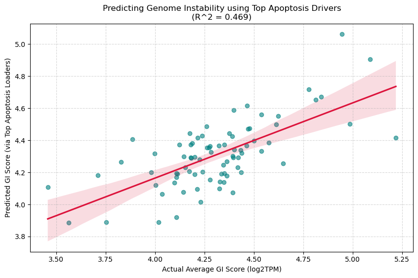

```python
from sklearn.linear_model import LinearRegression # Linear Regression for modeling
from sklearn.metrics import r2_score, mean_squared_error # Metrics for evaluating regression performance
import pandas as pd # Pandas for data manipulation
import matplotlib.pyplot as plt # Matplotlib for plotting
import seaborn as sns # Seaborn for enhanced data visualization

# 1. DEFINE THE TOP LOADING GENES (Unique set from PC1 and PC2)
# ------------------------------------------------------------------
top_pc1 = ['SOCS3', 'CD44', 'BCL2A1', 'CAMK2A', 'CASP1', 'IL6', 'CSF1R', 'IL1B', 'ITGB4', 'FOS']
top_pc2 = ['CAMK2A', 'PRKCB', 'SNCA', 'PAK1', 'FGFR2', 'FGFR3', 'IL1B', 'ANGPT2', 'TLR4', 'NRG3']

# Combine and remove duplicates
top_apoptosis_features = list(set(top_pc1 + top_pc2))

# 2. PREPARE X (Features) AND y (Target)
# ------------------------------------------------------------------
# X: Only the top loading apoptosis genes
X_regression = X2[top_apoptosis_features]

# y: The average Genome Instability score calculated from hallmark X
y_target = X.mean(axis=1)

print(f"Regression using {len(top_apoptosis_features)} features to predict GI Score.")

# 3. TRAIN THE MODEL
# ------------------------------------------------------------------
reg_model = LinearRegression()
reg_model.fit(X_regression, y_target)

# 4. EVALUATE PERFORMANCE
# ------------------------------------------------------------------
y_pred = reg_model.predict(X_regression)
r2 = r2_score(y_target, y_pred)
mse = mean_squared_error(y_target, y_pred)

print(f"--- MODEL RESULTS ---")
print(f"R^2 Score: {r2:.4f}")
print(f"Mean Squared Error: {mse:.4f}\n")

# 5. RANK FEATURE IMPORTANCE (Coefficients)
# ------------------------------------------------------------------
coefficients = pd.DataFrame({
    'Gene': top_apoptosis_features,
    'Weight': reg_model.coef_
}).sort_values(by='Weight', ascending=False)

print("Gene Weights in predicting Genome Instability:")
print(coefficients.to_string(index=False))

# 6. VISUALIZATION: ACTUAL VS PREDICTED
# ------------------------------------------------------------------
plt.figure(figsize=(10, 6))
sns.regplot(x=y_target, y=y_pred, scatter_kws={'alpha':0.6, 'color':'teal'}, line_kws={'color':'crimson'}) # Scatter plot of actual vs predicted GI scores with a regression line
plt.xlabel("Actual Average GI Score (log2TPM)")
plt.ylabel("Predicted GI Score (via Top Apoptosis Loaders)")
plt.title(f"Predicting Genome Instability using Top Apoptosis Drivers\n(R^2 = {r2:.3f})")
plt.grid(True, linestyle='--', alpha=0.5)
plt.show()
```

#### Phase 1 Results:

This model achieved an R^2 score of 0.469, incidating that 46.9% of the variance in genome instabilty is explained by the genes that drive the most variance in the apoptosis hallmark. Genes such as CASP1 (0.119 weight) are primary predictors of high instabilty, while genes like CD44 (-0.100) indicated that higher expression correlates with a more stable genome in this specific subset.

#### Phase 2:

```
--- TOP 10 APOPTOSIS PREDICTORS OF GENOME INSTABILITY ---
 Gene  R2_Score
LMNB1  0.795778
LMNB2  0.722144
CASP2  0.718751
 PLK1  0.685299
BRCA2  0.679445
 CDK1  0.646223
CCNB1  0.629793
 MLH1  0.613456
BIRC5  0.577028
BRCA1  0.563899
```

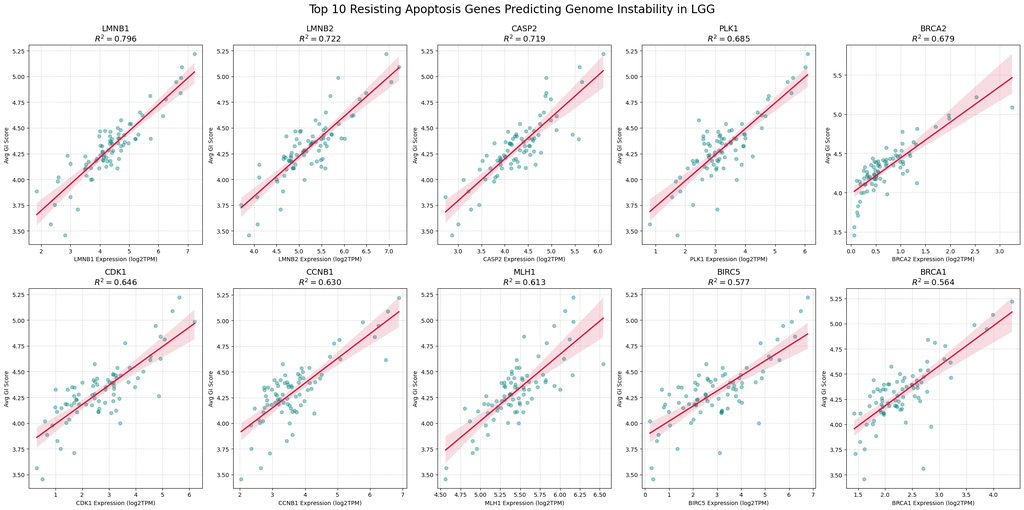

```python
# %% CONSOLIDATED LINEAR REGRESSION: TOP 10 PREDICTORS
#################################################################
from sklearn.linear_model import LinearRegression # Linear Regression for modeling
import matplotlib.pyplot as plt # Matplotlib for plotting
import seaborn as sns # Seaborn for enhanced data visualization
import pandas as pd # Pandas for data manipulation

# 1. RUN REGRESSION LOOP FOR EVERY GENE
# ---------------------------------------------------------------
regression_results = []
target_y = X['GI_Score'].values # Genome Instability Target
trained_models = {} # Initialize the dictionary to save models

for gene in X2.columns:
    # Reshape the feature for the model
    X_gene = X2[gene].values.reshape(-1, 1)

    # Fit the linear regression model
    reg = LinearRegression().fit(X_gene, target_y)

    # Save the model
    trained_models[gene] = reg

    # Store results
    regression_results.append({
        'Gene': gene,
        'R2_Score': reg.score(X_gene, target_y)
    })

# 2. IDENTIFY THE TOP 10
# ---------------------------------------------------------------
top_10_df = pd.DataFrame(regression_results).sort_values(by='R2_Score', ascending=False).head(10)

print("--- TOP 10 APOPTOSIS PREDICTORS OF GENOME INSTABILITY ---")
print(top_10_df.to_string(index=False))
print("\n")

# 3. GRAPH THE 10 SCATTERPLOTS (2x5 Grid)
# ---------------------------------------------------------------
# Create a large figure with 10 subplots
fig, axes = plt.subplots(2, 5, figsize=(25, 12))
axes = axes.flatten() # Makes it easier to loop through the 10 spots

for i, (index, row) in enumerate(top_10_df.iterrows()):
    gene_name = row['Gene']
    r2_val = row['R2_Score']

    # Plotting the raw data (teal dots) + regression line (crimson line)
    sns.regplot(
        ax=axes[i],
        x=X2[gene_name],
        y=target_y,
        scatter_kws={'alpha':0.4, 'color':'teal'},
        line_kws={'color':'crimson'}
    )

    # Visual formatting for each subplot
    axes[i].set_title(f"{gene_name}\n$R^2 = {r2_val:.3f}$", fontsize=14)
    axes[i].set_xlabel(f"{gene_name} Expression (log2TPM)")
    axes[i].set_ylabel("Avg GI Score")
    axes[i].grid(True, linestyle='--', alpha=0.5)

# Adjust layout so titles don't overlap
plt.tight_layout()
plt.suptitle("Top 10 Resisting Apoptosis Genes Predicting Genome Instability in LGG", y=1.03, fontsize=20)
plt.show()
```

#### Phase 2 Results:

The genes: LMNB1, LMNB2, CASP2, PLK1, BRCA2, CDK1, CCNB1, MLH1, BIRC5, and BRCA1 were the genes with the highest R^2 values. These genes show a tight distribution around the regression line, indicating they are highly sensitive biomarkers for genomic instabilbity.

#### Phase 3:

The final training step involved taking the 10 strongest individual predictors identified in phase 2 and integrating them into a single multivariate model. This model uses the collective information from all 10 high correlation genes simultaneously.

The model takes the raw numerical expression levels for these 10 genes and multiplies them by a weight that represents each gene's influence on the prediction. The specific values for these weights are determined using the Ordinary Least Squares algorithm, which analyzes the entire 80 patient dataset to find a set a weights that minimizes the residual sum of squares.

```
Multivariate R²: 0.943
    Gene  Coefficient
7   MLH1     0.207398
2  CASP2     0.089358
9  BRCA1     0.074544
0  LMNB1     0.072675
5   CDK1     0.059095
8  BIRC5    -0.051770
4  BRCA2     0.050450
3   PLK1     0.046550
1  LMNB2     0.018318
6  CCNB1     0.008435
```

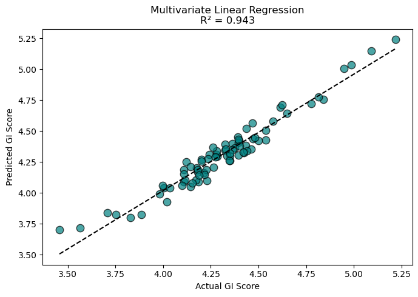

```python
# Get top 10 genes
top_10_genes = top_10_df['Gene'].tolist()

# Build feature matrix and target
X_multi = X2[top_10_genes]
y_multi = target_y

# Fit single multivariate model
multi_model = LinearRegression()
multi_model.fit(X_multi, y_multi)

y_pred = multi_model.predict(X_multi)
r2 = multi_model.score(X_multi, y_multi)

# Coefficients
coef_df = pd.DataFrame({
    'Gene': top_10_genes,
    'Coefficient': multi_model.coef_
}).sort_values('Coefficient', key=abs, ascending=False) # Sort by absolute value of coefficients

print(f"Multivariate R²: {r2:.3f}")
print(coef_df)

# Plot 1: Predicted vs Actual
plt.figure(figsize=(7, 5))
plt.scatter(y_multi, y_pred, alpha=0.7, edgecolors='k', s=80, color='teal') # Scatter plot of actual vs predicted GI scores for the multivariate model
m, b = np.polyfit(y_multi, y_pred, 1)
plt.plot(sorted(y_multi), [m*x + b for x in sorted(y_multi)], 'k--', linewidth=1.5)
plt.xlabel("Actual GI Score")
plt.ylabel("Predicted GI Score")
plt.title(f"Multivariate Linear Regression\nR² = {r2:.3f}")
plt.tight_layout()
plt.show()
```

#### Phase 3 Results:

The optimized model achieved a multivariate R^2 of 0.943. This proves that the expression profiles of these 10 resisting apoptosis genes are strongly correlated with the Genome Instability hallmark.

### Validation:

```
--- PREPARING VALIDATION DATA ---

--- VALIDATING MULTIVARIATE MODEL: TOP 18 PCA LOADINGS ---
Top 18 Validation R²: -0.045
```

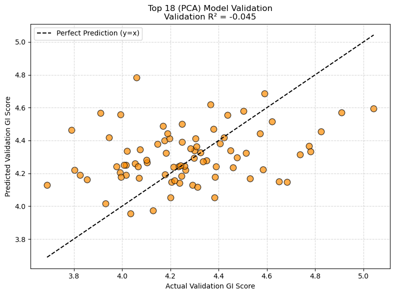

```
--- VALIDATING UNIVARIATE MODELS (TOP 10) ---
```

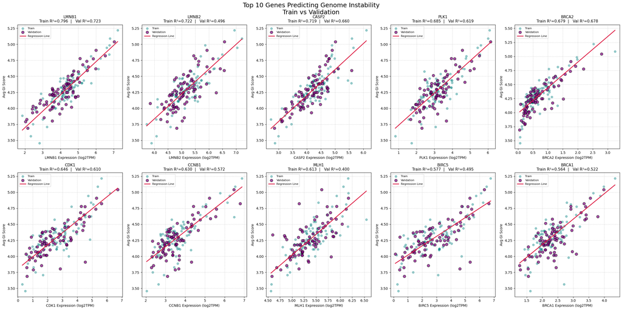

```
--- VALIDATING MULTIVARIATE MODEL: TOP 10 GENES ---
Top 10 Validation R²: 0.894
```

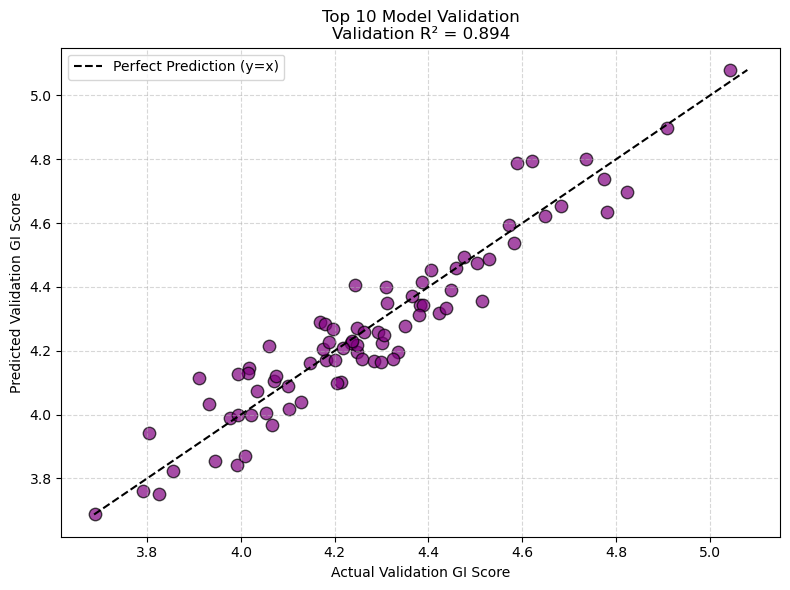

```python
# =================================================================
# VALIDATION PHASE
# =================================================================
import numpy as np # Numpy for numerical operations
from sklearn.metrics import r2_score # R² score for evaluating regression performance
import pandas as pd # Pandas for data manipulation
import matplotlib.pyplot as plt # Matplotlib for plotting

# 1. LOAD AND PREPARE VALIDATION DATA
# ------------------------------------------------------------------
print("--- PREPARING VALIDATION DATA ---")
val_metadata = pd.read_csv('../Data/VALIDATION_SET_GSE62944_metadata.csv', index_col=0, header=0)
val_data = pd.read_csv('../Data/VALIDATION_SET_GSE62944_subsample_log2TPM.csv', index_col=0, header=0)

# Filter for LGG samples
val_cancer_samples = val_metadata[val_metadata['cancer_type'] == 'LGG'].index
val_LGG_data = val_data[val_cancer_samples]

# Subset using the exact gene lists established during training
val_X = val_LGG_data.loc[[g for g in gene_list_genome_instability if g in val_LGG_data.index]].T
val_X2 = val_LGG_data.loc[[g for g in gene_list_resist_apoptosis if g in val_LGG_data.index]].T

# 2. COMPUTE VALIDATION TARGET (GI SCORE)
# ------------------------------------------------------------------
# Safely remove GI_Score if it exists to prevent feature matching errors
if 'GI_Score' in val_X.columns:
    val_X = val_X.drop(columns=['GI_Score'])

# Calculate the target variable exactly as it was done in training (mean of GI genes)
val_target_y = val_X.mean(axis=1)

# 3. VALIDATE MULTIVARIATE MODEL (TOP 18 PCA LOADINGS)
# ------------------------------------------------------------------
print("\n--- VALIDATING MULTIVARIATE MODEL: TOP 18 PCA LOADINGS ---")
missing_top18 = [g for g in top_apoptosis_features if g not in val_X2.columns]

if missing_top18:
    print(f"Warning: Missing genes in validation set: {missing_top18}")
else:
    val_X_top18 = val_X2[top_apoptosis_features]
    val_pred_top18 = reg_model.predict(val_X_top18)
    val_r2_top18 = reg_model.score(val_X_top18, val_target_y)

    print(f"Top 18 Validation R²: {val_r2_top18:.3f}")

    plt.figure(figsize=(8, 6))
    plt.scatter(val_target_y, val_pred_top18, alpha=0.7, edgecolors='k', s=80, color='darkorange') # Scatter plot of actual vs predicted GI scores for the top 18 PCA loadings model

    min_val = min(val_target_y.min(), val_pred_top18.min())
    max_val = max(val_target_y.max(), val_pred_top18.max())
    plt.plot([min_val, max_val], [min_val, max_val], 'k--', linewidth=1.5, label='Perfect Prediction (y=x)')

    plt.xlabel("Actual Validation GI Score")
    plt.ylabel("Predicted Validation GI Score")
    plt.title(f"Top 18 (PCA) Model Validation\nValidation R² = {val_r2_top18:.3f}")
    plt.legend()
    plt.grid(True, linestyle='--', alpha=0.5)
    plt.tight_layout()
    plt.show()

# 4. VALIDATE UNIVARIATE MODELS (10 INDIVIDUAL SCATTERPLOTS)
# ------------------------------------------------------------------
print("\n--- VALIDATING UNIVARIATE MODELS (TOP 10) ---")
fig, axes = plt.subplots(2, 5, figsize=(25, 12))
axes = axes.flatten()

for i, (index, row) in enumerate(top_10_df.iterrows()):
    gene_name = row['Gene']
    train_r2 = row['R2_Score']

    # Retrieve the saved model from training
    reg = trained_models[gene_name]

    # Plot Training points
    axes[i].scatter(X2[gene_name], target_y, alpha=0.4, color='teal', label='Train')

    # Plot Validation points and Regression Line
    if gene_name in val_X2.columns:
        axes[i].scatter(val_X2[gene_name], val_target_y, alpha=0.7, color='purple', edgecolors='k', s=60, label='Validation')

        x_min = min(X2[gene_name].min(), val_X2[gene_name].min())
        x_max = max(X2[gene_name].max(), val_X2[gene_name].max())
        x_line = np.linspace(x_min, x_max, 100).reshape(-1, 1)
        y_line = reg.predict(x_line)

        axes[i].plot(x_line, y_line, color='crimson', linewidth=2, label='Regression Line') # Adding a regression line for better visualization of the relationship in the validation set

        val_r2 = reg.score(val_X2[gene_name].values.reshape(-1, 1), val_target_y)
        val_r2_text = f"  Val R²={val_r2:.3f}"
    else:
        x_min, x_max = X2[gene_name].min(), X2[gene_name].max()
        x_line = np.linspace(x_min, x_max, 100).reshape(-1, 1)
        y_line = reg.predict(x_line)
        axes[i].plot(x_line, y_line, color='crimson', linewidth=2, label='Regression Line')
        val_r2_text = "  Val: gene missing"

    axes[i].set_title(f"{gene_name}\nTrain R²={train_r2:.3f}  | {val_r2_text}", fontsize=11)
    axes[i].set_xlabel(f"{gene_name} Expression (log2TPM)")
    axes[i].set_ylabel("Avg GI Score")
    axes[i].legend(fontsize=8)
    axes[i].grid(True, linestyle='--', alpha=0.5)

plt.tight_layout()
plt.suptitle("Top 10 Genes Predicting Genome Instability\nTrain vs Validation", y=1.03, fontsize=18)
plt.show()

# 5. VALIDATE MULTIVARIATE MODEL (TOP 10 PREDICTORS)
# ------------------------------------------------------------------
print("\n--- VALIDATING MULTIVARIATE MODEL: TOP 10 GENES ---")
missing_top10 = [g for g in top_10_genes if g not in val_X2.columns]

if missing_top10:
    print(f"Warning: Missing genes in validation set: {missing_top10}")
else:
    val_X_top10 = val_X2[top_10_genes]
    val_pred_top10 = multi_model.predict(val_X_top10)
    val_r2_top10 = multi_model.score(val_X_top10, val_target_y)

    print(f"Top 10 Validation R²: {val_r2_top10:.3f}")

    plt.figure(figsize=(8, 6))
    plt.scatter(val_target_y, val_pred_top10, alpha=0.7, edgecolors='k', s=80, color='purple') # Scatter plot of actual vs predicted GI scores for the top 10 predictors multivariate model

    min_val = min(val_target_y.min(), val_pred_top10.min())
    max_val = max(val_target_y.max(), val_pred_top10.max())
    plt.plot([min_val, max_val], [min_val, max_val], 'k--', linewidth=1.5, label='Perfect Prediction (y=x)')

    plt.xlabel("Actual Validation GI Score")
    plt.ylabel("Predicted Validation GI Score")
    plt.title(f"Top 10 Model Validation\nValidation R² = {val_r2_top10:.3f}")
    plt.legend()
    plt.grid(True, linestyle='--', alpha=0.5)
    plt.tight_layout()
    plt.show()
```

#### Validation Testing Results:

##### Top 18 PCA Model

The validation of the model built on the 18 top PCA loaders resulted in an R^2 value of -0.045. This indicates that the model performed worse than using the mean values of the validation data. The 18 genes were selected because they represented the highest variance in the training dataset. However, these results prove that the variance captured by PCA in the first dataset does not translate to the redictive relationship in the scond dataset. This confirms that simply bieng a high-variance gene does not make that gene a reliable predictor across different patient groups. This variable was underfit. It did not match the training data extremely well (R^2 = 0.469), but it did not at all correlate with the validation dataset.

##### Univariate Top 10 Validation

BRCA2 is the most consistent individual predictor, with almost zero loss in accuracy between datasets.

LMNB1 remains the strongest individual predictor in the validation set, even with a slight drop in performance.

##### Top 10 Combined Multivariate Validation

The multivariate model using the top 10 individual predictors is the most successful model in this study. An R^2 of 0.894 on a separate validation datset is a very high result for transcriptomatic data. This signifies that the weighted combined expression of these 10 genes can account for approximately 89.4% of the variance in genome instability. While the performance dropped slightly from the training data (R^2 = 0.943), the model remains accurate. This indicates that the weights assigned to these genes during training are applicable to other patients with brain lower grade glioma.

#### Validation Conclusions

These results show that selecting features based on correlation with the target (the Top 10 genes) is far more effective for prediction than selecting features based on unsupervised variance (the Top 18 PCA genes).

The 0.894 validation R^2 provides quantitative evidence that the relationship between Resisting Apoptosis and Genome Instability is a stable biological feature of brain low grade glioma.

Genes involved in DNA repair and nuclear integrity, specifically LMNB1, BRCA2, and CASP2, are the most reliable transcriptomic indicators of a tumor's genomic state.

### Improvements Using Regularization

Although the top 10 multivariate model successfully fit the dataset, we decided to implement three regularization metrics to see if our dataset of resisting apoptosis genes could be reduced and still accurately predict average genome instability score, or if our model could be improved.

### Improvement 1: Lasso Regularization

To further refine our 10 gene multivariate model, we applied Lasso Regularization. The objective of this method is to apply a penalty to feature coefficients, forcing the model to reduce the weights of redundant or non-impactful genes to exactly zero, implying that they are not critical to the success of the model.

```
--- OPTIMIZING TOP 10 MODEL WITH LASSO REGULARIZATION ---
Optimal Penalty (Alpha) chosen: 0.0006

Lasso Train R²:      0.943
Lasso Validation R²: 0.892

Lasso Coefficients (Notice any that dropped to 0.0):
 Gene  Lasso_Weight
 MLH1      0.076527
LMNB1      0.075523
 CDK1      0.061521
BIRC5     -0.060331
CASP2      0.056625
BRCA1      0.042286
 PLK1      0.039597
BRCA2      0.028044
LMNB2      0.010942
CCNB1      0.005903
```

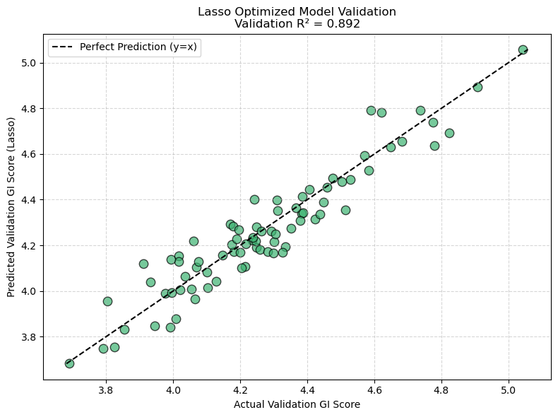

```python
from sklearn.linear_model import LassoCV # Lasso regression with built-in cross-validation to find the optimal regularization strength
from sklearn.preprocessing import StandardScaler # StandardScaler for feature scaling, which is crucial for Lasso regression to perform effectively
from sklearn.metrics import r2_score # R² score for evaluating regression performance
import pandas as pd # Pandas for data manipulation
import numpy as np # Numpy for numerical operations
import matplotlib.pyplot as plt # Matplotlib for plotting

print("--- OPTIMIZING TOP 10 MODEL WITH LASSO REGULARIZATION ---")

# 1. SCALE THE DATA (Crucial for Lasso)
# ------------------------------------------------------------------
scaler = StandardScaler()

# Fit the scaler ON THE TRAINING DATA ONLY, then transform both sets
X_train_scaled = scaler.fit_transform(X_multi)
X_val_scaled = scaler.transform(val_X_top10)

# 2. INITIALIZE AND TRAIN LASSO WITH CROSS-VALIDATION
# ------------------------------------------------------------------
# LassoCV automatically tests hundreds of penalties to find the optimal one
# Balances accuracy with feature reduction, using 5-fold cross validation.
lasso_cv = LassoCV(cv=5, random_state=42)
lasso_cv.fit(X_train_scaled, y_multi)

# 3. EVALUATE PERFORMANCE
# ------------------------------------------------------------------
y_train_pred_lasso = lasso_cv.predict(X_train_scaled)
y_val_pred_lasso = lasso_cv.predict(X_val_scaled)

train_r2_lasso = r2_score(y_multi, y_train_pred_lasso)
val_r2_lasso = r2_score(val_target_y, y_val_pred_lasso)

print(f"Optimal Penalty (Alpha) chosen: {lasso_cv.alpha_:.4f}\n")
print(f"Lasso Train R²:      {train_r2_lasso:.3f}")
print(f"Lasso Validation R²: {val_r2_lasso:.3f}\n")

# 4. EXTRACT AND RANK THE NEW COEFFICIENTS
# ------------------------------------------------------------------
lasso_coefs = pd.DataFrame({
    'Gene': top_10_genes,
    'Lasso_Weight': lasso_cv.coef_
}).sort_values('Lasso_Weight', key=abs, ascending=False)

print("Lasso Coefficients (Notice any that dropped to 0.0):")
print(lasso_coefs.to_string(index=False))

# 5. VISUALIZE LASSO VALIDATION
# ------------------------------------------------------------------
plt.figure(figsize=(8, 6))
plt.scatter(val_target_y, y_val_pred_lasso, alpha=0.7, edgecolors='k', s=80, color='mediumseagreen') # Scatter plot of actual vs predicted GI scores for the Lasso-optimized model

min_val = min(val_target_y.min(), y_val_pred_lasso.min())
max_val = max(val_target_y.max(), y_val_pred_lasso.max())
plt.plot([min_val, max_val], [min_val, max_val], 'k--', linewidth=1.5, label='Perfect Prediction (y=x)')

plt.xlabel("Actual Validation GI Score")
plt.ylabel("Predicted Validation GI Score (Lasso)")
plt.title(f"Lasso Optimized Model Validation\nValidation R² = {val_r2_lasso:.3f}")
plt.legend()
plt.grid(True, linestyle='--', alpha=0.5)
plt.tight_layout()
plt.show()
```

#### Results:

We expected the Lasso algorithm to remove highly correlated genes (such as CCNB1 and LMNB2) to simplify the model. However, the output shows that all 10 genes were retained. The reason for this likely is due to the optimal penalty value (Alpha) that was selected during the cross validation: 0.0006. This extremely low penalty indicates that when the algorithm attempted to apply a stricter penalty and remove genes, the R^2 value dropped significantly. Therefore, this attempt at regularization confirms that all of the 10 genes contribue a unique, non-redundant variance necessary to predict the Genome Instability score at a high accuracy.

While no genes were removed, the Lasso regularization did significantly alter how the model prioritizes the features compared to the standard Ordinary Least Squares regression. In the standard model, MLH1 had a large coefficient of 0.207, which the Lasso algorithm reduced to 0.076. The model also elevated LMNB1 to be almost as impactful (0.075). Overall, the Lasso algorithm compressed the total range of the weights, distributing the predictive reponsibility more evenly across the top features.

The application of the Lasso penalty resulted in a negligible 0.002 decrease in validation accuracy. The Lasso optimization proves that our initial 10 gene selection was already highly efficient. Because a strict mathematical penalty could not remove any features without harming the model's performance, we can conclude that this specific set of 10 genes represents a minimal, essential transcriptomic pattern linking apoptotic resistance to genomic instability in LGG.

### Improvement 2: Ridge Regularization

Following the Lasso analysis, we applied Ridge Regularization to the 10 gene model. While Lasso applies an absolute penalty that can force coefficients to zero, Ridge applies a squared penalty. This contricts large coefficients, forcing the model to distribute predictive weight more evenly across all features without entirely removing them.

```
--- OPTIMIZING TOP 10 MODEL WITH RIDGE REGULARIZATION ---
Optimal Penalty (Alpha) chosen: 11.4976

Ridge Train R²:      0.937
Ridge Validation R²: 0.888

Ridge Coefficients (Notice none are 0.0):
 Gene  Ridge_Weight
 MLH1      0.071049
CASP2      0.054024
LMNB1      0.053507
BRCA1      0.040216
BRCA2      0.030894
 CDK1      0.029677
 PLK1      0.026939
LMNB2      0.025029
BIRC5     -0.010360
CCNB1      0.009792
```

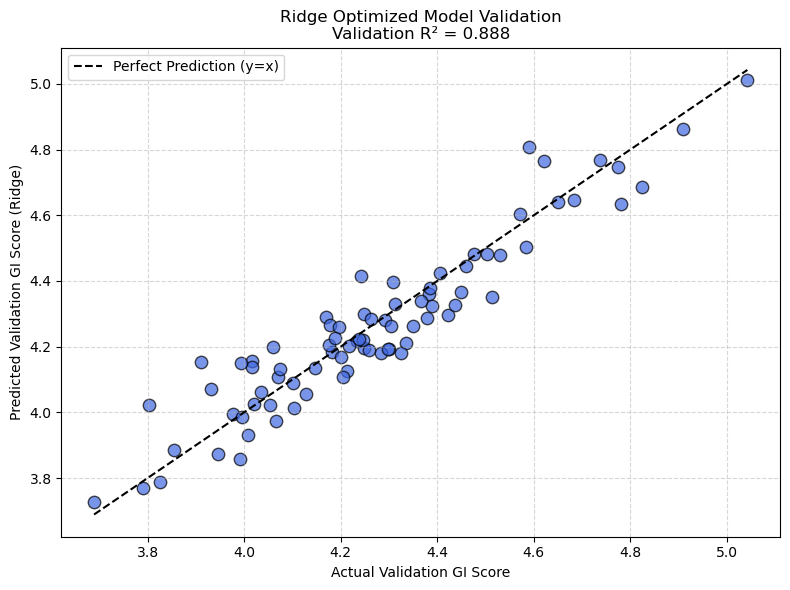

```python
from sklearn.linear_model import RidgeCV # Ridge regression with built-in cross-validation to find the optimal regularization strength
from sklearn.metrics import r2_score # R² score for evaluating regression performance
import pandas as pd # Pandas for data manipulation
import numpy as np # Numpy for numerical operations
import matplotlib.pyplot as plt # Matplotlib for plotting

print("--- OPTIMIZING TOP 10 MODEL WITH RIDGE REGULARIZATION ---")

# 1. INITIALIZE AND TRAIN RIDGE WITH CROSS-VALIDATION
# ------------------------------------------------------------------
# RidgeCV tests various penalty values automatically.
# Define a wide range of potential alphas for the model to test.
alphas_to_test = np.logspace(-3, 3, 100)
ridge_cv = RidgeCV(alphas=alphas_to_test, cv=5)

# Assuming X_train_scaled and y_multi from the Lasso step are still active
ridge_cv.fit(X_train_scaled, y_multi)

# 2. EVALUATE PERFORMANCE
# ------------------------------------------------------------------
y_train_pred_ridge = ridge_cv.predict(X_train_scaled)
y_val_pred_ridge = ridge_cv.predict(X_val_scaled)

train_r2_ridge = r2_score(y_multi, y_train_pred_ridge)
val_r2_ridge = r2_score(val_target_y, y_val_pred_ridge)

print(f"Optimal Penalty (Alpha) chosen: {ridge_cv.alpha_:.4f}\n")
print(f"Ridge Train R²:      {train_r2_ridge:.3f}")
print(f"Ridge Validation R²: {val_r2_ridge:.3f}\n")

# 3. EXTRACT AND RANK THE NEW COEFFICIENTS
# ------------------------------------------------------------------
ridge_coefs = pd.DataFrame({
    'Gene': top_10_genes,
    'Ridge_Weight': ridge_cv.coef_
}).sort_values('Ridge_Weight', key=abs, ascending=False)

print("Ridge Coefficients (Notice none are 0.0):")
print(ridge_coefs.to_string(index=False))

# 4. VISUALIZE RIDGE VALIDATION
# ------------------------------------------------------------------
plt.figure(figsize=(8, 6))
plt.scatter(val_target_y, y_val_pred_ridge, alpha=0.7, edgecolors='k', s=80, color='royalblue') # Scatter plot of actual vs predicted GI scores for the Ridge-optimized model

min_val = min(val_target_y.min(), y_val_pred_ridge.min())
max_val = max(val_target_y.max(), y_val_pred_ridge.max())
plt.plot([min_val, max_val], [min_val, max_val], 'k--', linewidth=1.5, label='Perfect Prediction (y=x)')

plt.xlabel("Actual Validation GI Score")
plt.ylabel("Predicted Validation GI Score (Ridge)")
plt.title(f"Ridge Optimized Model Validation\nValidation R² = {val_r2_ridge:.3f}")
plt.legend()
plt.grid(True, linestyle='--', alpha=0.5)
plt.tight_layout()
plt.show()
```

#### Results:

During cross-validation, the algorithm selected an optimal penalty (Alpha) of 11.4976. This is a substantial penalty compared to the Lasso moel. As a result, we observe a significant compression in the calculated weights. The Ridge penalty compressed the MLH1 coefficient weight from 0.207 to 0.071.

Becuase Ridge squares the weights, it prevents any single gene from disproportionately driving the prediction. The model is forced to distribute the calucation across all co-expressed genes. For example, the cell-cylce regulators (CDK1, PLK1, and CCNB1) and the structural genes (LMNB1 and LMNB2) all maintain moderate, positive wieghts ranging from 0.009 to 0.053. Additionally, as expected with the Ridge penalty, no gene was dropped to a weight of 0.

The Ridge model resulted in a slight decreae in validation accuracy, going from an R^2 of 0.894 to 0.888. Because our standard 10 gene model already demonstrated excellent generalization, it was not suffering from significant overfitting. By applying a high penalty, the Ridge algorithm constrained the model, restricting the coefficients so much that the model lost some of its ability to accurately map the true biological relationship.

### Improvement 3: Elastic Net Regularization

As a final optimization step, we applied Elastic Net Regularization. This method combines both the Lasso (L1) and Ridge (L2) penalties in an attempt to balance feature elimination with coefficient compression. The algorithm uses cross-validation to find the optimal ratio (Rho) between the two constraints.

```
--- OPTIMIZING TOP 10 MODEL WITH ELASTIC NET REGULARIZATION ---
Optimal Penalty (Alpha) chosen:   0.0758
Optimal L1 Ratio (Rho) chosen:    0.1
Elastic Net Train R²:             0.936
Elastic Net Validation R²:        0.886

Elastic Net Coefficients:
 Gene  Elastic_Weight
 MLH1        0.073330
LMNB1        0.060858
CASP2        0.055656
BRCA1        0.039591
BRCA2        0.030321
 PLK1        0.021972
 CDK1        0.021834
LMNB2        0.019066
CCNB1        0.002548
BIRC5        0.000000
```

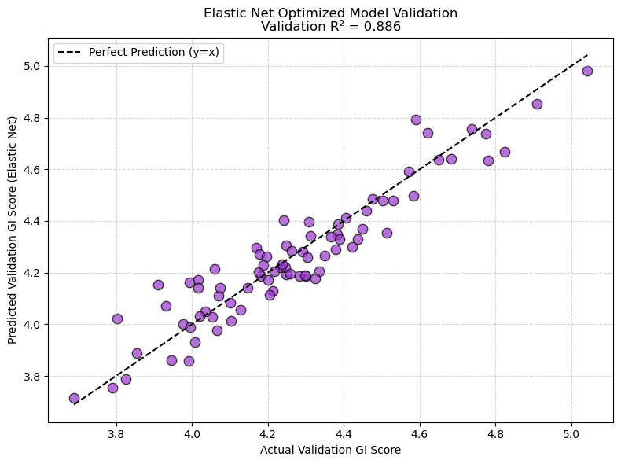

```python
from sklearn.linear_model import ElasticNetCV # Elastic Net regression with built-in cross-validation to find the optimal combination of L1 and L2 penalties
from sklearn.metrics import r2_score # R² score for evaluating regression performance
import pandas as pd # Pandas for data manipulation
import numpy as np # Numpy for numerical operations
import matplotlib.pyplot as plt # Matplotlib for plotting

print("--- OPTIMIZING TOP 10 MODEL WITH ELASTIC NET REGULARIZATION ---")

# 1. INITIALIZE AND TRAIN ELASTIC NET WITH CROSS-VALIDATION
# ------------------------------------------------------------------
# Provide a range of l1_ratios. The algorithm will test these alongside automatically generated alpha penalties to find the optimal combination.
ratios_to_test = [.1, .5, .7, .9, .95, .99, 1]
elastic_cv = ElasticNetCV(l1_ratio=ratios_to_test, cv=5, random_state=42)

# Use the scaled data from the earlier steps
elastic_cv.fit(X_train_scaled, y_multi)

# 2. EVALUATE PERFORMANCE
# ------------------------------------------------------------------
y_train_pred_elastic = elastic_cv.predict(X_train_scaled)
y_val_pred_elastic = elastic_cv.predict(X_val_scaled)

train_r2_elastic = r2_score(y_multi, y_train_pred_elastic)
val_r2_elastic = r2_score(val_target_y, y_val_pred_elastic)

print(f"Optimal Penalty (Alpha) chosen:   {elastic_cv.alpha_:.4f}")
print(f"Optimal L1 Ratio (Rho) chosen:    {elastic_cv.l1_ratio_}")
print(f"Elastic Net Train R²:             {train_r2_elastic:.3f}")
print(f"Elastic Net Validation R²:        {val_r2_elastic:.3f}\n")

# 3. EXTRACT AND RANK THE NEW COEFFICIENTS
# ------------------------------------------------------------------
elastic_coefs = pd.DataFrame({
    'Gene': top_10_genes,
    'Elastic_Weight': elastic_cv.coef_
}).sort_values('Elastic_Weight', key=abs, ascending=False)

print("Elastic Net Coefficients:")
print(elastic_coefs.to_string(index=False))

# 4. VISUALIZE ELASTIC NET VALIDATION
# ------------------------------------------------------------------
plt.figure(figsize=(8, 6))
plt.scatter(val_target_y, y_val_pred_elastic, alpha=0.7, edgecolors='k', s=80, color='darkorchid') # Scatter plot of actual vs predicted GI scores for the Elastic Net-optimized model

min_val = min(val_target_y.min(), y_val_pred_elastic.min())
max_val = max(val_target_y.max(), y_val_pred_elastic.max())
plt.plot([min_val, max_val], [min_val, max_val], 'k--', linewidth=1.5, label='Perfect Prediction (y=x)')

plt.xlabel("Actual Validation GI Score")
plt.ylabel("Predicted Validation GI Score (Elastic Net)")
plt.title(f"Elastic Net Optimized Model Validation\nValidation R² = {val_r2_elastic:.3f}")
plt.legend()
plt.grid(True, linestyle='--', alpha=0.5)
plt.tight_layout()
plt.show()
```

#### Results:

The cross-valdiation selected an Alpha penatly of 0.0758 and a Rho value of 0.1. The Rho value of 0.1 describes that the final penalty applied was 90% Ridge and 10% Lasso. This demonstrates that for this specific dataset, compressing the weights across correlated genes was mathematically more effective at reducing error than dropping features.

However, even though the model was 90% Ridge, the 10% Lasso penalty still exerted an impact on the model. The algorithm determned that BIRC5 was entirely redundant under this configuration, reducing its coefficient to 0. Similar to the pure Ridge model, the dominant weight of MLH1 was compressed from its standard weight of 0.207 down to o.073. The remaining predicted load was distributed across the other 8 retained genes.

Overall, the Elastic Net model yielded the lowest validation accuracy of the four iterations tested, with an R^2 value of 0.886. However, this is not a bad score, and it could indicated that BIRC5 isn't critical to predicting Genome Instablity if the other coeffients are shifted around.

### Improvements Conclusions:

We have now tested our 10 gene set against standard linear regression and three forms of regularization. The standard Ordinary Least Squares model had a validation R^2 value of 0.894, indicating the highest accuracy. The Lasso model had a validation R^2 of 0.892, retaining all 10 features with a slight accuracy loss. The Ridge model had a validation R^2 of 0.888, compressing the weights of the genes and slighlty reducing accuracy. Finally, the Elastic Net model had a validation R^2 of 0.886, but it was able to drop BIRC5 as a significant gene without much accuracy loss.

Overall, our compresensive testing confirms that our standard Multivariate Linear Regression model is the best model. The 10 genes identitied during the initial R^2 screening refresent a highly refined feature set. Applying regularized penalties restricts the model's ability to map the true variance of the data, thereby decreasing predictive accuracy on external validation sets. With the Elastic Net Regularization only dropping a single gene at the expense of some accuracy, we have decided to proceed with the unpenalized 10 gene linear regression model for our final biological analysis.

## Verify and validate your analysis:

### Verification Metric: The Coefficient of Determination

To verify the true generalizability of our optimal 10 gene multivariate linear regression model, we evaluated its performance on a completely unseen test dataset, ensuring our model accurately maps the biological relationship between apoptotic resistance and genomic instability in LGG. The metric of evaluation used was the Coefficient of Determination (R^2). This metric quantifies the proportion of the variance in the variance of the dependent variable (the actual Genome Instability score) that is predictable from the independent variables (the 10 gene feature set).

Mathematically this metric compares the sum of squared errors of our model against the total sum of squares of the baseline data:

R^2 = 1 - (Sum of Squared Residuals)/(Total Sum of Squares)

An R^2 of 1.0 indicates perfect prediction, and an R^2 of 0.0 indicates the model performs no better than simply guessing the average Genome Instability score for every patient. By using R^2 we can state exactly what percentage of genomic instability is mathematically explained by our 10 genes correlated with Resisting Apoptosis.

```
--- PREPARING TEST DATA ---

--- TESTING MULTIVARIATE MODEL: TOP 10 GENES ---
Top 10 Test R²: 0.908

Model Coefficients (Established during training phase):
 Gene  Coefficient
 MLH1     0.207398
CASP2     0.089358
BRCA1     0.074544
LMNB1     0.072675
 CDK1     0.059095
BIRC5    -0.051770
BRCA2     0.050450
 PLK1     0.046550
LMNB2     0.018318
CCNB1     0.008435
```

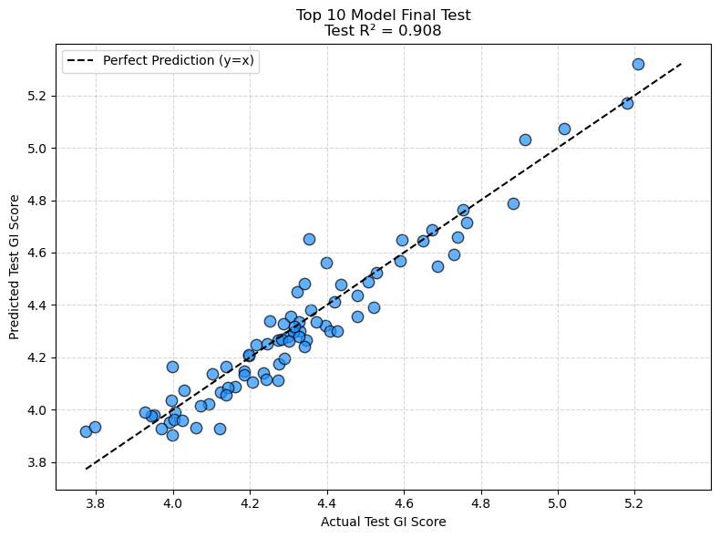

```python
# =================================================================
# FINAL TESTING PHASE
# =================================================================
import numpy as np # Numpy for numerical operations
from sklearn.metrics import r2_score # R² score for evaluating regression performance
import pandas as pd # Pandas for data manipulation
import matplotlib.pyplot as plt # Matplotlib for plotting

# 1. LOAD AND PREPARE TEST DATA
# ------------------------------------------------------------------
print("--- PREPARING TEST DATA ---")
test_metadata = pd.read_csv('../Data/TEST_SET_GSE62944_metadata.csv', index_col=0, header=0)
test_data = pd.read_csv('../Data/TEST_SET_GSE62944_subsample_log2TPM.csv', index_col=0, header=0)

# Filter for LGG samples
test_cancer_samples = test_metadata[test_metadata['cancer_type'] == 'LGG'].index
test_LGG_data = test_data[test_cancer_samples]

# Subset using the exact gene lists established during training
test_X = test_LGG_data.loc[[g for g in gene_list_genome_instability if g in test_LGG_data.index]].T
test_X2 = test_LGG_data.loc[[g for g in gene_list_resist_apoptosis if g in test_LGG_data.index]].T

# 2. COMPUTE TEST TARGET (GI SCORE)
# ------------------------------------------------------------------
# Safely remove GI_Score if it exists to prevent feature matching errors
if 'GI_Score' in test_X.columns:
    test_X = test_X.drop(columns=['GI_Score'])

# Calculate the target variable exactly as it was done in training
test_target_y = test_X.mean(axis=1)

# 3. TEST MULTIVARIATE MODEL (TOP 10 GENES)
# ------------------------------------------------------------------
print("\n--- TESTING MULTIVARIATE MODEL: TOP 10 GENES ---")
missing_top10 = [g for g in top_10_genes if g not in test_X2.columns]

if missing_top10:
    print(f"Warning: Missing genes in test set: {missing_top10}")
else:
    test_X_top10 = test_X2[top_10_genes]

    # Predict using the original unpenalized multi_model
    test_pred_top10 = multi_model.predict(test_X_top10)
    test_r2_top10 = multi_model.score(test_X_top10, test_target_y)

    print(f"Top 10 Test R²: {test_r2_top10:.3f}\n")

    # NEW: EXTRACT AND PRINT COEFFICIENTS
    # ------------------------------------------------------------------
    # Values are extracted from the pre-trained model to confirm the exact mathematical equation applied to the test data.
    test_coef_df = pd.DataFrame({
        'Gene': top_10_genes,
        'Coefficient': multi_model.coef_
    }).sort_values('Coefficient', key=abs, ascending=False)

    print("Model Coefficients (Established during training phase):")
    print(test_coef_df.to_string(index=False))
    print("\n")

    # 4. VISUALIZE TEST RESULTS
    # ------------------------------------------------------------------
    plt.figure(figsize=(8, 6))
    plt.scatter(test_target_y, test_pred_top10, alpha=0.7, edgecolors='k', s=80, color='dodgerblue') # Scatter plot of actual vs predicted GI scores for the top 10 predictors multivariate model on the test set

    min_val = min(test_target_y.min(), test_pred_top10.min())
    max_val = max(test_target_y.max(), test_pred_top10.max())
    plt.plot([min_val, max_val], [min_val, max_val], 'k--', linewidth=1.5, label='Perfect Prediction (y=x)')

    plt.xlabel("Actual Test GI Score")
    plt.ylabel("Predicted Test GI Score")
    plt.title(f"Top 10 Model Final Test\nTest R² = {test_r2_top10:.3f}")
    plt.legend()
    plt.grid(True, linestyle='--', alpha=0.5)
    plt.tight_layout()
    plt.show()
```

#### Test Data Results:

Applying our unpenalized 10 gene model to the new test data yielded an R^2 score of 0.908. The scatterplot visually confirms this, as the test data points cluster tightly around the dashed line representing perfect prediction. The model successfully predicted the continuous gradient of genomic instability, maintaining high accuracy across a range of GI scores.

This model is performing exceptionally well. We can conclude this by comparing the performance across all three data phases:

Training: R^2 = 0.943

Valdiation: R^2 = 0.894

Final Testing: R^2 = 0.908

The stability across independent datasets represents that the model is not overfit. A final test of 0.908 means that 90.8% of the variance in genome instability in this new dataset is directly explained by the expression levels of 10 genes from the Resisting Apoptosis hallmark. This provides quantitative proof that in Brain Lower Grade Glioma, the transcriptomic programming utilized to Resist Apoptosis is highly correlated with the mechanisms that lead to Genome Instability.

Previous literature examining the effect of certain genes on glioma outcomes and disease behavior were able to validate the genes used by the model to predict genome instability.

LMNB1 proved to be one of the strongest predictors of genome instability, with an individual R^2 score of 0.795778. Zhou et al. (2021) confirmed the significance of LMNB1 in glioma disease progression, finding that LMNB1 was highly expressed in gliomas. Higher levels of LMNB1 gene expression led to worsened survival rates in glioma patients. In colon cancer, Izdebska et al. (2018) found evidence to suggest that this gene leads to ‘mitotic catastrophe’, situations where cells divide with severe defects. The consequences of mitotic catastrophe – defects in DNA leading to greater mutations and genome instability – align with our findings of LMNB1 being a strongly correlated predictor of genome instability score.

Geng et al. (2018), in a bioinformatics analysis examining gene expression in glioma patients, identified 15 core biomarkers associated with the survival outcomes of glioma patients. Three of the core genes identified were CDK1, BIRC5, CCNB1 – all three were negatively correlated with patient survival in Geng et al.’s analysis. CDK1, BIRC5, and CCNB1 were also identified as three of the top 10 apoptosis genes predicting genome instability that constituted our model. Existing literature identifying a relationship between these genes and decreased patient survival validates that these genes are indeed strong predictors of genome instability – decreased patient survival is likely due to more malignant tumors with greater genome instability that enables its growth and spread.

BIRC5 was another strong predictor of genome instability score identified in our model. Conde et al. (2017) found that higher levels of BIRC5 in glioma cells cause greater chromosomal instability and increase the survival of cells with mitotic defects, suggesting an increase in genome instability. These findings strongly support our model which likewise identifies BIRC5 as a strong predictor of genome instability.

## Conclusions and Ethical Implications:

Understanding the top ten resisting apoptosis genes predicting genome instability may provide insights into genes to target and regulate to decrease genome instability and decrease progression of LGG. LGG, with its relatively slow growth rate, can go undetected for years. When they are detected, the notion of the tumor being “low-grade” and less aggressive may lead to tough decisions for clinicians between the need for intervention and mere observation of the tumor (Giantini-Larsen, 2022). However, it is important to remember that LGG can transform into a higher-grade, more aggressive glioma and that the behavior and malignancy of cancer can change. Genomic instability is a major contributing factor in the severity and aggressiveness of gliomas. Therefore, it is helpful to have a model such as the one implemented above that can take certain gene expression levels, such as resisting apoptosis gene levels, to predict genomic instability. Higher predicted genomic instability scores may signify a need for greater care and intervention to prevent the progression of aggressive LGG growth into a more severe glioma, whereas lower predicted genomic instability scores may suggest observation of the tumor over time, with assumptions that it is a less aggressive glioma. However, it is important to refine the model and test its accuracy on more patient samples before relying on it to predict genome instability and influence decisions regarding management of the disease.

## Limitations and Future Work:

Despite strong relationships to genome instability identified in specific resisting apoptosis genes, our PCA plots more generally did not find a strong relationship between resisting apoptosis genes and genome instability hallmark expression. Due to LGG being characterized by tumors graded as less severe and slow-growing, LGG may not have been the ideal cancer type to analyze genome instability hallmarks in.

However, future work may look to examine GBM instead, which encompasses more severe and aggressive grades of glioma. Because of the more aggressive nature of GBM compared to LGG, it would be interesting to see if there was a stronger relationship between the resisting apoptosis and genome instability hallmarks. Additionally, further analysis of the ability of resisting apoptosis gene expression to predict whether a glioma was low-grade or a higher-grade glioblastoma could be another interesting approach to examine.

## References:

- Bready, D., & Placantonakis, D. G. (2019). Molecular Pathogenesis of Low-Grade Glioma. Neurosurgery clinics of North America, 30(1), 17–25. https://doi.org/10.1016/j.nec.2018.08.011
- Cao, J., Yan, W., Zhan, Z., Hong, X., & Yan, H. (2023). Epidemiology and risk stratification of low-grade gliomas in the United States, 2004-2019: A competing-risk regression model for survival analysis. Frontiers in oncology, 13, 1079597. https://doi.org/10.3389/fonc.2023.1079597
- Conde, M., Michen, S., Wiedemuth, R. et al. Chromosomal instability induced by increased BIRC5/Survivin levels affects tumorigenicity of glioma cells. BMC Cancer 17, 889 (2017). https://doi.org/10.1186/s12885-017-3932-y
- Geng, Rong-Xin, Li, Ning, Xu, Yang, Liu, Jun-hui, Yuan, Fan-en, Sun, Qian, Liu, Bao-Hui, Chen, Qian-Xue, Identification of Core Biomarkers Associated with Outcome in Glioma: Evidence from Bioinformatics Analysis, Disease Markers, 2018, 3215958, 16 pages, 2018. https://doi.org/10.1155/2018/3215958
- Giantini-Larsen, A. M., Pannullo, S., & Juthani, R. G. (2022). Challenges in the Diagnosis and Management of Low-Grade Gliomas. World Neurosurgery, 166, 313–320. https://doi.org/10.1016/j.wneu.2022.06.074
- Izdebska, M., Gagat, M., & Grzanka, A. (2018). Overexpression of lamin B1 induces mitotic catastrophe in colon cancer LoVo cells and is associated with worse clinical outcomes. International Journal of Oncology, 52, 89-102. https://doi.org/10.3892/ijo.2017.4182
- Jiang, X., Shi, Y., Chen, X., Xu, H., Huang, X., Li, L., & Pu, J. (2022). The N6-Methylandenosine-Related Gene BIRC5 as a Prognostic Biomarker Correlated With Cell Migration and Immune Cell Infiltrates in Low Grade Glioma. Frontiers in molecular biosciences, 9, 773662. https://doi.org/10.3389/fmolb.2022.773662
- Karsonovich T, Gasalberti DP, Rayi A. Low-Grade Gliomas. [Updated 2025 Dec 13]. In: StatPearls [Internet]. Treasure Island (FL): StatPearls Publishing; 2026 Jan-. Available from: https://www.ncbi.nlm.nih.gov/books/NBK560668/
- Ludwig PE, Das JM. Histology, Glial Cells. [Updated 2023 May 1]. In: StatPearls [Internet]. Treasure Island (FL): StatPearls Publishing; 2026 Jan-. Available from: https://www.ncbi.nlm.nih.gov/books/NBK441945/
- Low-grade glioma treatment. (n.d.). St. Jude Care & Treatment. Retrieved April 9, 2026, from https://www.stjude.org/care-treatment/treatment/childhood-cancer/brain-tumors/low-grade-glioma.html
- Toader, C., Eva, L., Costea, D., Corlatescu, A. D., Covache-Busuioc, R. A., Bratu, B. G., Glavan, L. A., Costin, H. P., Popa, A. A., & Ciurea, A. V. (2023). Low-Grade Gliomas: Histological Subtypes, Molecular Mechanisms, and Treatment Strategies. Brain sciences, 13(12), 1700. https://doi.org/10.3390/brainsci13121700
- Schaff, L. R., Ioannou, M., Geurts, M., Van Den Bent, M. J., Mellinghoff, I. K., & Schreck, K. C. (2024). State of the art in low-grade glioma management: Insights from isocitrate dehydrogenase and beyond. American Society of Clinical Oncology Educational Book, 44(3), e431450. https://doi.org/10.1200/EDBK_431450
- Zhang, A., Guo, Z., Ren, J. X., Chen, H., Yang, W., Zhou, Y., Pan, L., Chen, Z., Ren, F., Chen, Y., Zhang, M., Peng, F., Chen, W., Wang, X., Zhang, Z., & Wu, H. (2023). Development of an MCL-1-related prognostic signature and inhibitors screening for glioblastoma. Frontiers in pharmacology, 14, 1162540. https://doi.org/10.3389/fphar.2023.1162540
- Zhou, D., Wang, M., Zhang, Y., Wang, K., Zhao, M., Wang, Y., Wang, X., Yu, R., & Zhou, X. (2021). Screening and identification of LMNB1 and DLGAP5, two key biomarkers in gliomas. Bioscience Reports, 41(5). https://doi.org/10.1042/BSR20210231